# Dynamic range model in Stan

Alexa Fredston and Malin Pinsky

begun November 2020

```r
library(rstan)
library(rstanarm)
```

```r
library(tidybayes)
library(bayesplot)
library(tidyverse)
library(here)
```

## General notes

Useful sources for Bayesian population models and Bayesian implementation in R that we referenced while building this script:

- https://github.com/DanOvando/learn-stan
- https://arxiv.org/src/2002.02001v1/anc/Appendix_S1.pdf p. 72
- https://cchecastaldo.github.io/BayesianShortCourse/Syllabus.html
- https://mc-stan.org/docs/2_25/stan-users-guide/mark-recapture-models.html
- https://mc-stan.org/docs/2_25/functions-reference/nbalt.html (and entire manual)

## Model notes

- Stan can’t estimate discrete latent variables, so we’ve moved N from being discrete to continuous

## To-do (short term)

- Revisit choices of initial values, especially when adding in dimensions over which variables are indexed, which will reduce the total number of individuals in each cell
- Add random Poisson noise around estimates of N every year (took this out to ensure Stan model was working correctly)
- Move away from uniform priors (done?)
- Figure out how to deal with true NAs in data, which are instances with no samples of a patch in a year (not true zeroes, although I’ve replaced them with zeroes temporarily)
- Add stage structure and transition rates
- Add in dispersal between patches
- Replace r (and/or dispersal rates) with temperature-dependent functions
- Choose data models for all species (currently just modeling fluke)

## dan’s changes

OK, there’s a lot going on here.

- change estimation of N to estimation of process error terms
- basically get rid of population model….

What would this ideally look like?

If you’re observing total N across all age classes, you could just estimate N in each time step as a random walk / AR processm, where you can set an autocorrelation strength…

So then you can estimate a CV and an autocorrelation

## stage-prep model

Tried this version, but doesn’t really work with just one stage. Once we get multipple stages, can separate out recruitment and mortality.

here is a suggestion for an alternative model structure. Following the idea here, this is a simplified version with 1 “stage”, but can easily be generalized to multiple stages with length transition matrices

for time *t* and patche *p*, estimate

$$n_{t = 1,p} \sim negbinom(x,sigma_{obs})$$

for future time steps

$$n_{t,p} = n_{t-1,p}e^{-m} + r_{t,p}$$

where *r* is recruits is an AR1 process

$raw$ are independent recruitment deviates

$$raw_t \sim lnorm(-\sigma_r^2/2,\sigma_r)$$

$$r_{t=1,p} = raw_{t=1}$$

and

$$r_{t,p} = \alpha \times r_{t-1,p} + \sqrt{1 - \alpha^2}\times raw_t)$$

## AR1 Model

To keep is simpler for now, shifting this to just an autoregressive (AR) 1 model, where process error in time step t is potentially correlated with process error in time t - 1.

for time *t* and patche *p*, estimate

$$n_{t = 1,p} \sim negbinom(x,sigma_{obs})$$

for future time steps

$$n_{t,p} = n_{t-1,p}e^{r_{t,p}}$$

where *r* is is an AR1 process error term

$raw$ are independent recruitment deviates

$$raw_t \sim norm(-\sigma_r^2/2,\sigma_r)$$

$$r_{t=1,p} = raw_{t=1,p}$$

and

$$r_{t,p} = -\sigma_r^2/2 + \alpha \times (r_{t - 1,p} - -\sigma_r^2/2) + raw_{t=1,p}$$

and

$$\sigma_{obs} \sim normal(0.75, 0.25)$$

From there, we generate posterior predictive to the fits, and then use the posterior predictive to generate the predictions for the future, where now we generate both process error and observation error for the projected time steps

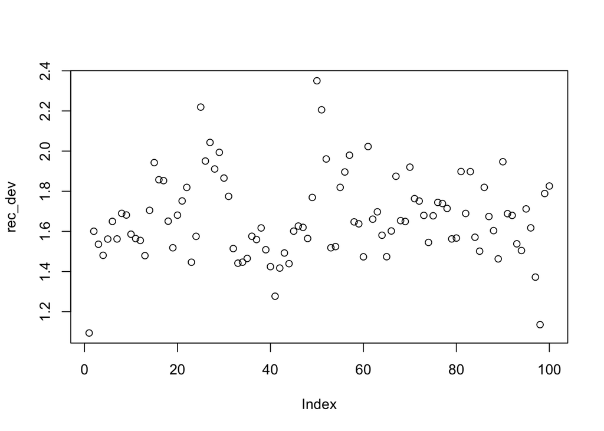

```r
sigma_r <- 0.2

p <- .5

y <- 100

rec_dev <- rep(0, y)

rec_dev[1] <- rlnorm(1, -sigma_r ^ 2 / 2, sigma_r)

for (t in 2:y) {
  rec_dev[t] <-
    rec_dev[t - 1] * p + rlnorm(1, -sigma_r ^ 2 / 2, sigma_r) * sqrt(1 - p ^ 2)
}

plot(rec_dev)
```

So just estimate a vector of recruitemtn deviates with the prior defined as above

```r
#library(rjags)

#library(MCMCvis)

# dogfish <- read_csv(here("processed-data","dogfish_prepped_data.csv"))

# dogfishTest <- dogfish %>%
#   filter(lengthclass=="adult") %>%
#   group_by(year) %>%
#   mutate(num_obs = sum(numlengthclass),
#          sd_obs = sd(numlengthclass)) %>% # this is standard deviation of different counts in a year, not of overall abundance over time
#   select(year, num_obs, sd_obs) %>%
#   distinct()
# moving away from spiny dogfish because it is massively overdispersed and no single distribution will be able to produce values at low densities (1, 3, 10...) and at very high densities (5000, 8000, 10000) of dogfish; will eventually need a mixture model, and/or to totally disregard small values and assume everything under some threshold is basically equivalent

fluke <- read_csv(here("processed-data","fluke_prepped_data.csv"))
fluke_lat_time <- fluke %>%
  mutate(lat_round = round(lat)) %>%
  filter(lengthclass=="adult",
         year>=1973,
         lat_round >= 34,
         lat_round < 43 # because we're just using nefsc survey for now, which rarely goes below 34N
         ) %>%
  group_by(year, lat_round) %>%
  summarise(num_obs = sum(numlengthclass)) %>%
  ungroup()
fluke_train <- fluke_lat_time %>%
  filter(year <= 2012)

fluke_test <- fluke_lat_time %>%
  filter(year > 2012)


head(fluke_lat_time)
```

```
## # A tibble: 6 x 3
##    year lat_round num_obs
##   <dbl>     <dbl>   <dbl>
## 1  1973        34      10
## 2  1973        35      17
## 3  1973        36     112
## 4  1973        37     171
## 5  1973        38     292
## 6  1973        39     338
```

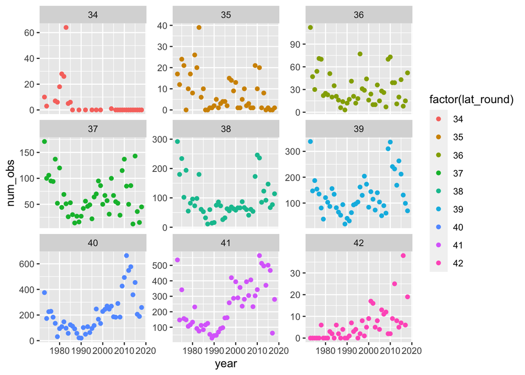

```r
fluke_lat_time %>%
ggplot(aes(year, num_obs, color = factor(lat_round))) +
  geom_point() +
  facet_wrap(~lat_round, scales = "free_y")
```

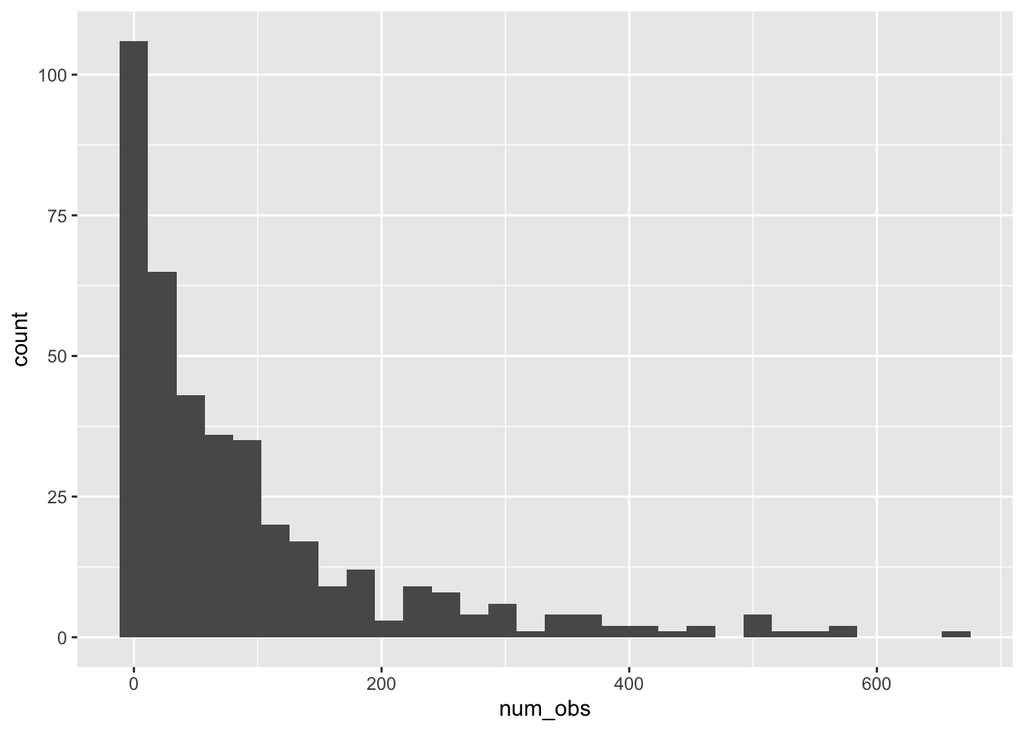

```r
fluke_lat_time %>%
ggplot(aes(num_obs)) +
  geom_histogram()
```

Here’s the stan script:

```stan
data{
int<lower=1> len_t; // the number of time points

int<lower=0> len_i; // number of patches

int<lower=0> y[len_i, len_t]; // defining y as an array of integers with patches as rows and years as columns

// data inputs
vector<lower=0>[len_i] z0; // vector of starting pop. values, one per patch

}

//transformed data{
//}

parameters{
row_vector[len_i] log_mean_rec; // average number of recruits per year

real<lower=0> sigma_r; // recruitment deviates CV

real<lower=0> phi_obs; // observation error

matrix[len_i,len_t-1] raw; // array of raw recruitment deviates

real<lower = 0, upper = 1> alpha; // autocorrelation parameter

real log_m; // average mortality, this is really not right... eventually would need to fix M and estimate F

vector<lower=1e3, upper=1e7>[len_i] gamma_shape0; // gamma parameter for process model at time step 1 - manually setting range
vector<lower=1, upper=1e3>[len_i] gamma_rate0; // gamma parameter for process model at time step 1 - manually setting range

}

transformed parameters {

matrix[len_i, len_t] y_hat; // estimated numbers in patch i and timestep t

matrix[len_i,len_t-1] rec_dev; // array of realized recruitment deviates

real m;

row_vector[len_i] mean_rec;

mean_rec = exp(log_mean_rec);

m = exp(log_m);

y_hat[1:len_i,1] = z0;

for (t in 2:len_t){

  if (t == 2){
  rec_dev[1:len_i,t-1]  =  raw[1:len_i,1];
  } else {

  rec_dev[1:len_i,t-1] = alpha * rec_dev[1:len_i,t-2] + sqrt(1 - pow(alpha,2)) * raw[1:len_i,t-1]; // recruitment deviates as an autocorrelated process

  }
  y_hat[1:len_i,t] = y_hat[1:len_i,t-1] * exp(-m) + mean_rec * exp(rec_dev[1:len_i,t-1]); // calculate population in each patch

} // close time loop

}

model{

phi_obs ~ normal(0.75, 0.25); // from https://mc-stan.org/docs/2_20/functions-reference/nbalt.html  phi = mu^2 / (sigma^2-mu)

log_m ~ normal(log(0.2),.05); // natural mortality prior

sigma_r ~ cauchy(0,.5); // process error prior

log_mean_rec ~ normal(log(50),2); // prior on mean number of recruits per patch

raw ~ normal(pow(-sigma_r,2)/2,sigma_r);

// observation model
for(t in 1:len_t) {

    for(i in 1:len_i){

      //raw[i,t] ~ normal(pow(-sigma_r,2)/2,sigma_r); // prior on raw process error

      y[i,t] ~ neg_binomial_2(y_hat[i,t], phi_obs); // this version of neg binom has a more familiar form

    }


}

}
```

Evaluating the model:

```r
summary(model1_fit)
```

[output not shown]

[output cut: 17259 more lines]

[output not shown]

```
## 'pars' not specified. Showing first 10 parameters by default.
```

```
## ci_level: 0.8 (80% intervals)
```

```
## outer_level: 0.95 (95% intervals)
```

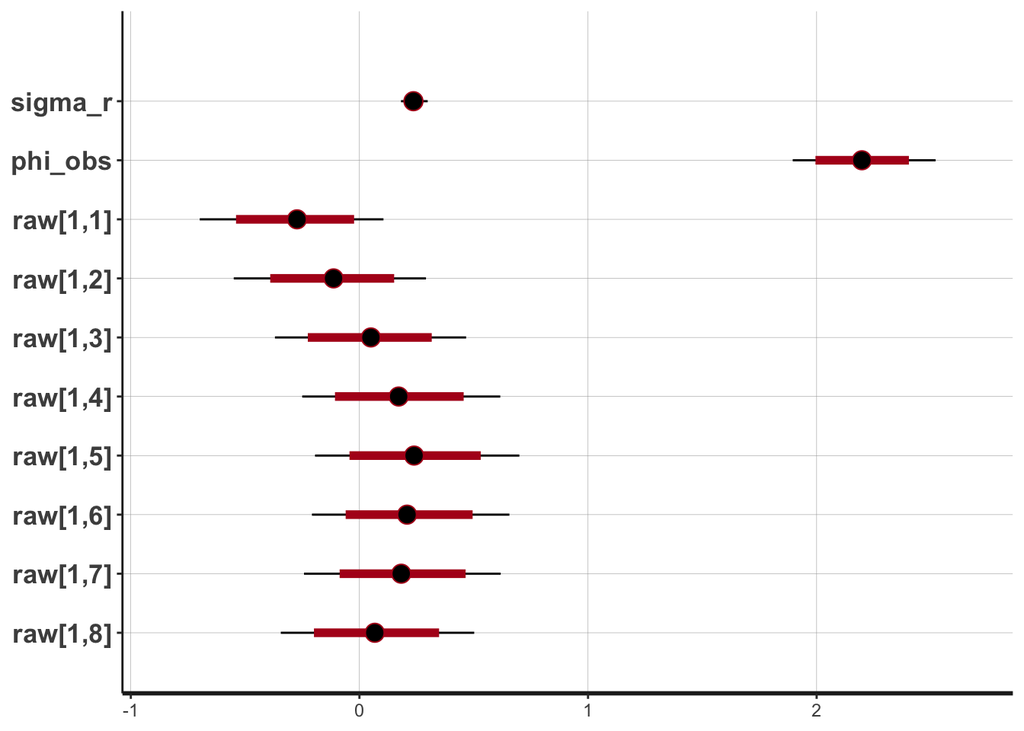

```r
plot(model1_fit)
```

```r
check_divergences(model1_fit)
```

```
## 0 of 10000 iterations ended with a divergence.
```

```r
# rstanarm::launch_shinystan(model1_fit)

# convert to a df


predicted_fluke <- tidybayes::gather_draws(model1_fit,y_hat[patch,year], n = 1000) %>%
         mutate(patch = as.numeric(patch),
         lat = patch + min(fluke_lat_time$lat_round) - 1,
         year = year + min(fluke_lat_time$year) - 1)

pp_predicted_fluke <- tidybayes::gather_draws(model1_fit,pp_y_hat[patch,year], n = 1000) %>%
         mutate(patch = as.numeric(patch),
         lat = patch + min(fluke_lat_time$lat_round) - 1,
         year = year + min(fluke_lat_time$year) - 1)

pp_projected_fluke <- tidybayes::gather_draws(model1_fit,pp_proj_y_hat[patch,year], n = 1000) %>%
         mutate(patch = as.numeric(patch),
         lat = patch + min(fluke_lat_time$lat_round) - 1,
         year = year + min(fluke_test$year) - 1)
```

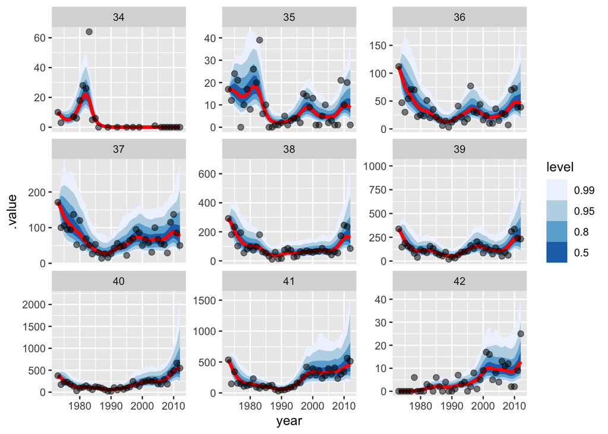

```r
predicted_fluke %>%
  ggplot() +
  stat_lineribbon(aes(x = year, y = .value),.width = c(.99, .95, .8, .5), color = "red") +
  geom_point(data = fluke_train %>% rename(lat = lat_round), aes(year, num_obs), size = 2,alpha = 0.5) +
  facet_wrap(~lat, scales = "free_y") +
  scale_fill_brewer()
```

Posterior predictive fits

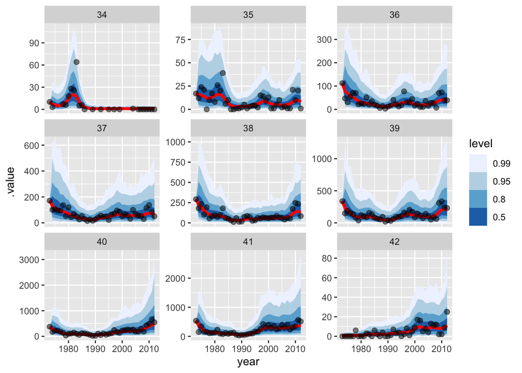

```r
pp_predicted_fluke %>%
  ggplot() +
  stat_lineribbon(aes(x = year, y = .value),.width = c(.99, .95, .8, .5), color = "red") +
  geom_point(data = fluke_train %>% rename(lat = lat_round), aes(year, num_obs), size = 2,alpha = 0.5) +
  facet_wrap(~lat, scales = "free_y") +
  scale_fill_brewer()
```

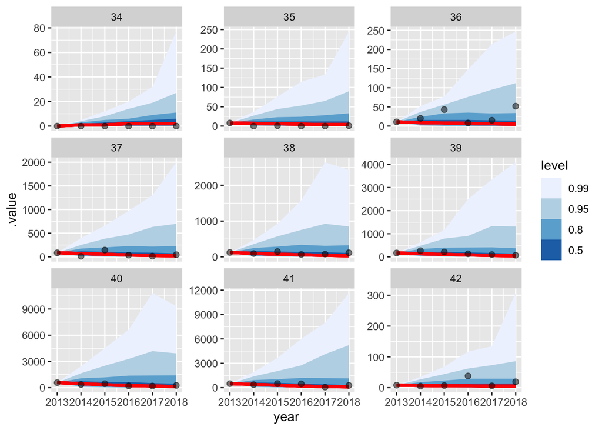

```r
pp_projected_fluke %>%
  ggplot() +
  stat_lineribbon(aes(x = year, y = .value),.width = c(.99, .95, .8, .5), color = "red") +
  geom_point(data = fluke_test %>% rename(lat = lat_round), aes(year, num_obs), size = 2,alpha = 0.5) +
  facet_wrap(~lat, scales = "free_y") +
  scale_fill_brewer()
```

```
## ci_level: 0.8 (80% intervals)
```

```
## outer_level: 0.95 (95% intervals)
```

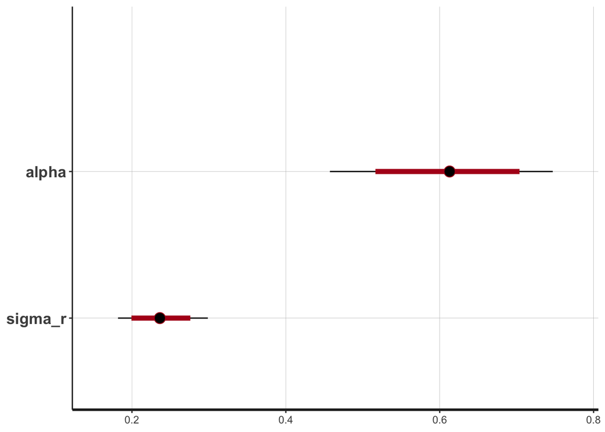

```r
plot(model1_fit, pars = c("alpha","sigma_r"))
```